# Machine_Learning_Project_NN

Nikolaos Nikolaou

1 October 2018

# **Synopsis**

Using devices such as Jawbone Up, Nike FuelBand, and Fitbit it is now possible to collect a large amount of data about personal activity relatively inexpensively. These type of devices are part of the quantified self movement – a group of enthusiasts who take measurements about themselves regularly to improve their health, to find patterns in their behavior, or because they are tech geeks. One thing that people regularly do is quantify **how much** of a particular activity they do, but they rarely quantify **how well** they do it. In this project, our goal will be to use data from accelerometers on the belt, forearm, arm, and dumbell of 6 participants. They were asked to perform barbell lifts correctly and incorrectly in 5 different ways.

Our goal is to predict the *manner in which they did the exercise*(variable classe in the training dataset)! Variable “**classe**” is a factor of 5 levels: **A** (exactly according to the specification), **B** (throwing the elbows to the front), **C** (lifting the dumbbell only halfway), **D** (lowering the dumbbell only halfway), **E** (throwing the hips to the front).

We will *built a model* and explain how we did it. We will explain how we used *cross validation* and what we think the expected *out of sample error* is. In addition, why we made the choices we did. Finally, we will also use our *prediction model* to predict 20 different test cases.

To ensure *reproducibility*, we will set the seed to 2018.

Finally, the final model will be selected between the models which will be created by 2 different procedures: *classification trees* & *random forests*

# **Analysis**

### How we used Cross Validation?

- We will use the training set & split it into training/test subsets
- We will reserve a training subset, the 70% of the original
- We will built a model using the training subset
- We will use the reserve test set(the remaining 30% of the original) to evaluate our model.

This will help us in gauging the effectiveness of our model’s performance.

Finally, we will use the original testing set to evaluate our choice.

### Some steps to begin with

```r
# English system language
Sys.setenv("LANGUAGE"="En")
Sys.setlocale("LC_ALL", "English")
```

## Data Processing

```r
set.seed(2018) # for reproducible analysis

# Let's load & read the datasets
pml_training <- read.csv(url("http://d396qusza40orc.cloudfront.net/predmachlearn/pml-training.csv"), na.strings=c("NA","#DIV/0!",""), header=TRUE)
dim(pml_training)
```

```
## [1] 19622   160
```

```r
pml_testing <- read.csv(url("http://d396qusza40orc.cloudfront.net/predmachlearn/pml-testing.csv"), na.strings=c("NA","#DIV/0!",""), header=TRUE)
dim(pml_testing)
```

```
## [1]  20 160
```

```r
# Let's have a look of our training dataset
str(pml_training) # We observe some NA's and some #DIV/0! values. After such an observation we ran again the loadings above to include na.strings
```

```
## 'data.frame':    19622 obs. of  160 variables:
##  $ X                       : int  1 2 3 4 5 6 7 8 9 10 ...
##  $ user_name               : Factor w/ 6 levels "adelmo","carlitos",..: 2 2 2 2 2 2 2 2 2 2 ...
##  $ raw_timestamp_part_1    : int  1323084231 1323084231 1323084231 1323084232 1323084232 1323084232 1323084232 1323084232 1323084232 1323084232 ...
##  $ raw_timestamp_part_2    : int  788290 808298 820366 120339 196328 304277 368296 440390 484323 484434 ...
##  $ cvtd_timestamp          : Factor w/ 20 levels "02/12/2011 13:32",..: 9 9 9 9 9 9 9 9 9 9 ...
##  $ new_window              : Factor w/ 2 levels "no","yes": 1 1 1 1 1 1 1 1 1 1 ...
##  $ num_window              : int  11 11 11 12 12 12 12 12 12 12 ...
##  $ roll_belt               : num  1.41 1.41 1.42 1.48 1.48 1.45 1.42 1.42 1.43 1.45 ...
##  $ pitch_belt              : num  8.07 8.07 8.07 8.05 8.07 8.06 8.09 8.13 8.16 8.17 ...
##  $ yaw_belt                : num  -94.4 -94.4 -94.4 -94.4 -94.4 -94.4 -94.4 -94.4 -94.4 -94.4 ...
##  $ total_accel_belt        : int  3 3 3 3 3 3 3 3 3 3 ...
##  $ kurtosis_roll_belt      : num  NA NA NA NA NA NA NA NA NA NA ...
##  $ kurtosis_picth_belt     : num  NA NA NA NA NA NA NA NA NA NA ...
##  $ kurtosis_yaw_belt       : logi  NA NA NA NA NA NA ...
```

[output cut: 86 more lines]

```r
library(caret) # Needed library

# Let's split the training dataset as we mentioned above
inTrain <- createDataPartition(pml_training$classe, p = 0.7, list = FALSE)
s_training <- pml_training[inTrain,] ; s_testing <- pml_training[-inTrain,]

# Let's have a brief look
dim(s_training) ; dim(s_testing) ; dim(s_training)[1]/dim(pml_training)[1]
```

```
## [1] 13737   160
```

```
## [1] 5885  160
```

```
## [1] 0.7000815
```

```r
# Let's remove the first 7 columns as they give info that we don't need them for our prediction model
s_training <- s_training[, -c(1:7)] ; s_testing <- s_testing[, -c(1:7)]

# Let's clean our train & test datasets from all those variables which have at least 30% of NAs.
z <- which(colSums(is.na(s_training)| s_training == "") > 0.3*dim(s_training)[1])
s_training <- s_training[,-z]
x <- colnames(s_training) ; y <- colnames(s_training[,-53])
s_testing <- s_testing[x] ; pml_testing <- pml_testing[y]

# Let's have a brief look again
dim(s_training) ; dim(s_testing) ; dim(pml_testing)
```

```
## [1] 13737    53
```

```
## [1] 5885   53
```

```
## [1] 20 52
```

### **Classification tree**

```r
# Needed libraries
library(rpart)
library(rpart.plot)
library(rattle)

r_part <- rpart(classe ~., data = s_training, method="class")

# We exhibit the results of classifications in Appendix - plot 1

# Let's predict
p_r_part <- predict(r_part, newdata = s_testing, type="class")
print(c_r_part <- confusionMatrix(p_r_part, s_testing$classe))
```

```
## Confusion Matrix and Statistics
##
##           Reference
## Prediction    A    B    C    D    E
##          A 1566  253   18  114   36
##          B   29  568   46   22   59
##          C   46  213  878   98  142
##          D   22   82   84  653   77
##          E   11   23    0   77  768
##
## Overall Statistics
##
##                Accuracy : 0.7533
##                  95% CI : (0.742, 0.7642)
##     No Information Rate : 0.2845
##     P-Value [Acc > NIR] : < 2.2e-16
##
##                   Kappa : 0.6862
##  Mcnemar's Test P-Value : < 2.2e-16
##
## Statistics by Class:
##
##                      Class: A Class: B Class: C Class: D Class: E
## Sensitivity            0.9355  0.49868   0.8558   0.6774   0.7098
## Specificity            0.9000  0.96713   0.8973   0.9461   0.9769
## Pos Pred Value         0.7881  0.78453   0.6376   0.7113   0.8737
## Neg Pred Value         0.9723  0.88936   0.9672   0.9374   0.9373
## Prevalence             0.2845  0.19354   0.1743   0.1638   0.1839
## Detection Rate         0.2661  0.09652   0.1492   0.1110   0.1305
## Detection Prevalence   0.3376  0.12302   0.2340   0.1560   0.1494
## Balanced Accuracy      0.9178  0.73291   0.8765   0.8118   0.8433
```

As we see, the accuracy of our prediction is 75.33% with expected out of sample error to be (1-0.7533)*100% = 24.67%! Let’s compare these results with the results of another prediction model to pick the best!

### **Random forests**

```r
# Needed libraries
library(randomForest)
library(repmis)

r_forest <- randomForest(classe ~., data = s_training)

# Let's predict
p_r_forest <- predict(r_forest, s_testing)
print(c_r_forest <- confusionMatrix(s_testing$classe, p_r_forest))
```

```
## Confusion Matrix and Statistics
##
##           Reference
## Prediction    A    B    C    D    E
##          A 1672    2    0    0    0
##          B    3 1133    3    0    0
##          C    0    5 1021    0    0
##          D    0    0   16  948    0
##          E    0    0    0    0 1082
##
## Overall Statistics
##
##                Accuracy : 0.9951
##                  95% CI : (0.9929, 0.9967)
##     No Information Rate : 0.2846
##     P-Value [Acc > NIR] : < 2.2e-16
##
##                   Kappa : 0.9938
##  Mcnemar's Test P-Value : NA
##
## Statistics by Class:
##
##                      Class: A Class: B Class: C Class: D Class: E
## Sensitivity            0.9982   0.9939   0.9817   1.0000   1.0000
## Specificity            0.9995   0.9987   0.9990   0.9968   1.0000
## Pos Pred Value         0.9988   0.9947   0.9951   0.9834   1.0000
## Neg Pred Value         0.9993   0.9985   0.9961   1.0000   1.0000
## Prevalence             0.2846   0.1937   0.1767   0.1611   0.1839
## Detection Rate         0.2841   0.1925   0.1735   0.1611   0.1839
## Detection Prevalence   0.2845   0.1935   0.1743   0.1638   0.1839
## Balanced Accuracy      0.9989   0.9963   0.9903   0.9984   1.0000
```

```r
# Graphical illustration of error rate in Appendix
```

# *Conclusion*

So, we will end our project with the use of random forests to predict the outcome variable classe in the testing set because of its better accuracy.

```r
print(predict(r_forest, pml_testing))
```

```
##  1  2  3  4  5  6  7  8  9 10 11 12 13 14 15 16 17 18 19 20
##  B  A  B  A  A  E  D  B  A  A  B  C  B  A  E  E  A  B  B  B
## Levels: A B C D E
```

# **Appendix**

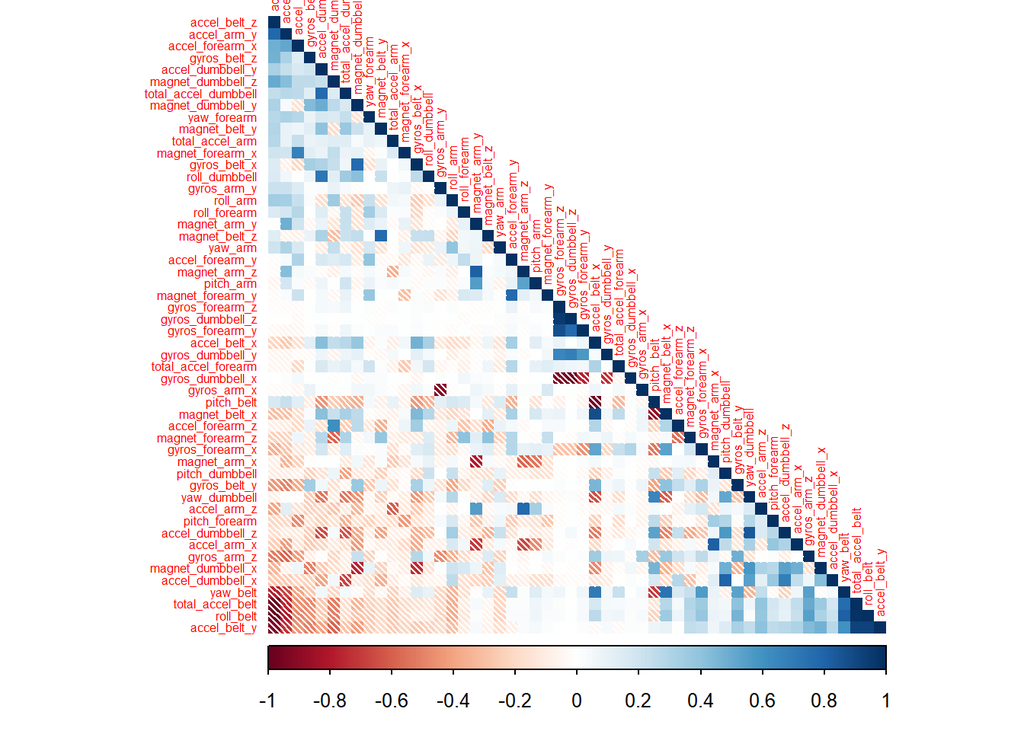

```r
# Correlation Plot
library(corrplot)
cor <- cor(s_training[,-53])
corrplot(cor, order = "FPC", type = "lower", method = "shade", tl.cex = 0.5)
```

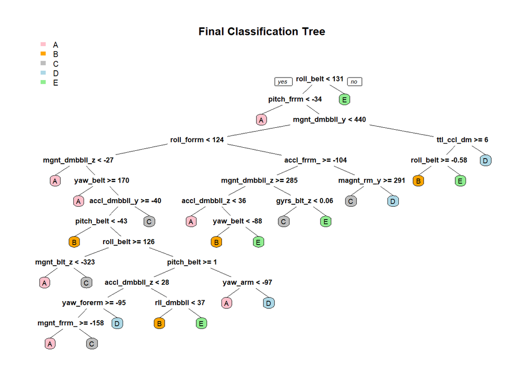

```r
# Classification tree method - plot 1
prp(r_part, varlen = 10, box.palette = list("pink", "orange", "gray", "lightblue", "lightgreen"), main = "Final Classification Tree")
```

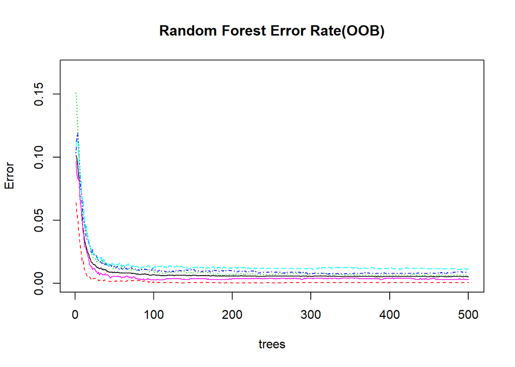

```r
# Random Forests method - plot 2 & 3
# Let's plot the error for all 5 different classes over the amount of trees
plot(r_forest, ylim = c(0, 0.17), main = "Random Forest Error Rate(OOB)")
```